# Traffic Sign Recognition Classifier

### Step 0 : Dependency Import

We first import all the necessary packages/dependencies that will be required in the project

```python
import cv2
import pickle
import matplotlib.pyplot as plt
import numpy as np
import os
import glob
import pandas as pd
import sklearn
import tensorflow as tf
import sys
import csv
import random
from tqdm import tqdm
from sklearn.metrics import confusion_matrix
from matplotlib import __version__ as plt__version
from math import ceil, pow

from utils import ImagePreprocessor

%matplotlib inline
```

### Step 1 : Loading Data

The data was downloaded before hand and placed in the dataset folder.

```
1. Download the data using `` wget``
2. Unzip using ``unzip ``
```

```python
# Load pickled data
training_file = 'dataset/train.p'
validation_file= 'dataset/valid.p'
testing_file = 'dataset/test.p'

with open(training_file, mode='rb') as f:
    training_data = pickle.load(f)
with open(validation_file, mode='rb') as f:
    valid_data = pickle.load(f)
with open(testing_file, mode='rb') as f:
    test_data = pickle.load(f)

x_train, y_train = training_data['features'], training_data['labels']
x_valid, y_valid = valid_data['features'], valid_data['labels']
x_test, y_test = test_data['features'], test_data['labels']
signnames = pd.read_csv('signnames.csv')['SignName']
```

```python
n_train = x_train.shape[0]
n_valid = x_valid.shape[0]
n_test = x_test.shape[0]
image_shape = x_train.shape
n_classes = np.unique(y_train).size

print("Number of Training examples : {}".format(n_train))
print("Number of Validation examples : {}".format(n_valid))
print("Number of Testing examples : {}".format(n_test))
print("Image data shape : {}".format(image_shape))
print("Number of Classes : {}".format(n_classes))
```

```
Number of Training examples : 34799
Number of Validation examples : 4410
Number of Testing examples : 12630
Image data shape : (34799, 32, 32, 3)
Number of Classes : 43
```

### Step 2 : Exploratory Data Analysis

From the distribution below we can conclude the following :

```
1. Some classes have very low representation, i.e. training images being < 250
2. The Train-Valid-Test are stratified splits, in proportion to the original data-set.
```

```python
# plot class frequency
def plot_frequency(unqiue,count,title,image_name):
    plt.figure(figsize=(12,6))
    plt.bar(unqiue, count)
    plt.grid()
    plt.title(title)
    plt.savefig('./output_images/'+image_name)
    plt.show()
```

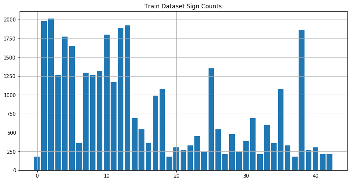

```python
unique_train, counts_train = np.unique(training_data['labels'], return_counts=True)
plot_frequency(unique_train,counts_train,title = "Train Dataset Sign Counts",image_name="Train_Dataset_Distribution.png")
```

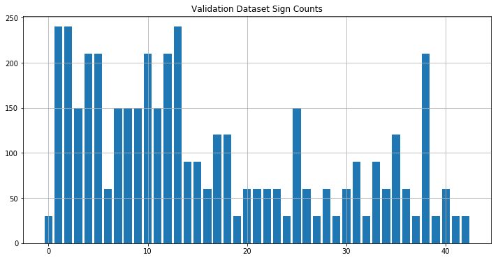

```python
unique_valid, counts_valid = np.unique(valid_data['labels'], return_counts=True)
plot_frequency(unique_valid,counts_valid,
               title = "Validation Dataset Sign Counts",image_name="Validation_Dataset_Distribution.png")
```

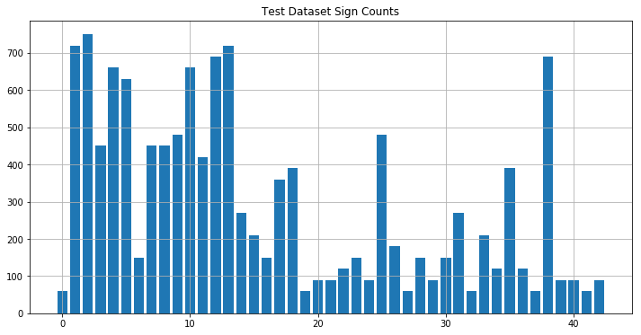

```python
unique_test, counts_test = np.unique(test_data['labels'], return_counts=True)
plot_frequency(unique_test,counts_test,
               title = "Test Dataset Sign Counts",image_name="Test_Dataset_Distribution.png")
```

#### We explore the Training data images along with the classes

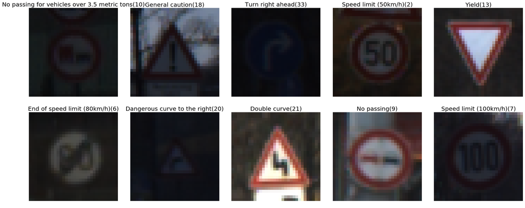

```python
signs_class=[]

with open('signnames.csv', 'rt') as csvfile:
    reader = csv.DictReader(csvfile, delimiter=',')
    for row in reader:
        signs_class.append((row['SignName']))

# Visualize the Train Images
fig, axs = plt.subplots(2, 5, figsize=(24, 10))  #axs[20]
axs = axs.flatten()

fig.tight_layout()

serial_number = 0
for i in range(10):
    index = random.randint(i, len(x_train))
    image = x_train[index].squeeze()
    axs[i].axis("off")
    axs[i].imshow(image)

    signs_name = signs_class[y_train[index]] + '(' + str(y_train[index]) + ')'

    axs[i].set_title(signs_name, fontsize=20)

fig.savefig('./output_images/visualize_training_data.png')
```

### Step 3 : Image Pre-processing

We run the image via basic image preprocessing to standardrize the data for better convergence of the model. The following steps have been used -

```
1. Equalizing the Y channel of the images instead of converting to GRAY SCALE.
2. Min-Max Normalization.
3. Adding the channel dimension.
```

```python
# Encapsulating all the operations in ImageProcessor Class
# Default values are set to true
processor = ImagePreprocessor()

# Transform all the datasets
x_train_processed = processor.preprocess(x_train)
x_valid_processed = processor.preprocess(x_valid)
x_test_processed = processor.preprocess(x_test)
```

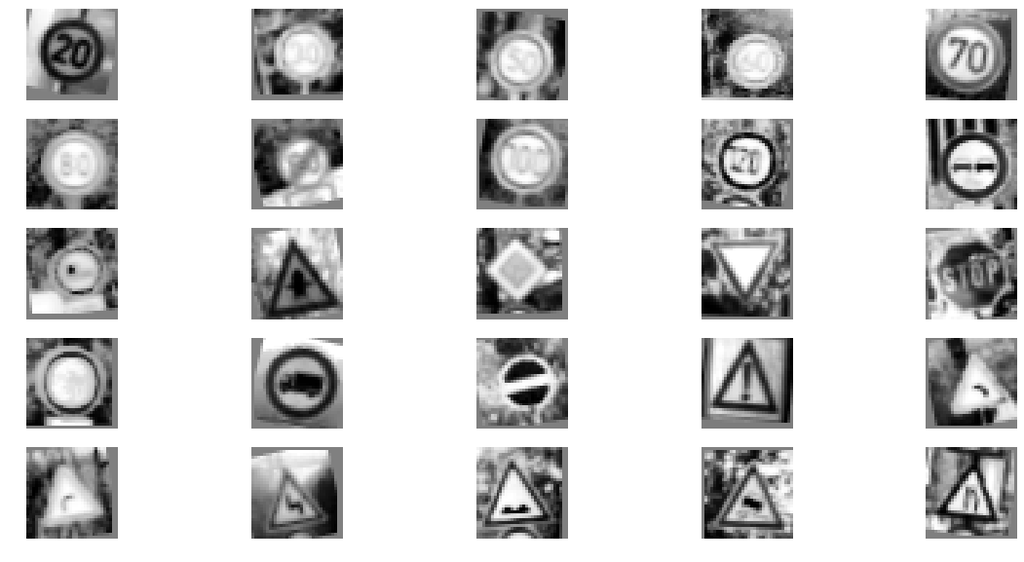

```python
f, axes = plt.subplots(5, 5,figsize=(20, 10))
#f.set_size_inches(A4_PORTRAIT)
c = 0
for row in axes:
    for ax in row:
        if c < n_classes:
            im = (x_train_processed[np.random.choice(np.where(y_train == c)[0], 1)] + 1) / 2
            ax.imshow(im[0,:,:,0], cmap='gray')
        ax.grid(False)
        ax.axis('off')
        c += 1
plt.savefig('./output_images/preprocessed_images.png')
plt.show()
```

## Step 4 : Data Augmentation

```python
unique, counts = np.unique(y_train, return_counts=True)
```

```python
target = 9000
x_augmented = []
y_augmented = []

for cls, count in tqdm(list(zip(unique, counts)), 'Data Augmentation'):
    diff = target - count
    x_augmented += processor.augment(x_train_processed[np.where(y_train == cls)[0]], diff)
    y_augmented += [cls for _ in range(diff)]

x_train_processed = np.concatenate([x_train_processed, np.array(x_augmented)])
y_train = np.concatenate([y_train, np.array(y_augmented)])
n_train = y_train.size

# After Data AUgmentation
print('Number of Training examples : {}'.format(n_train))
```

```
Number of Training examples : 387000
```

## Step 5 : Model Class

```python
def conv2d(x, kernel, input_depth, output_depth, stride=1, padding='VALID', mu=0, sigma=0.1):
    shape = (kernel, kernel, input_depth, output_depth)
    W = tf.Variable(tf.truncated_normal(shape=shape, mean=mu, stddev=sigma))
    b = tf.Variable(tf.zeros(output_depth))
    conv = tf.nn.conv2d(x, W, strides=[1, stride, stride, 1], padding=padding)
    conv = tf.nn.bias_add(conv, b)
    return conv


def fully_connected(x, input_size, output_size, mu=0, sigma=0.1):
    W = tf.Variable(tf.truncated_normal(shape=(input_size, output_size), mean=mu, stddev=sigma))
    b = tf.Variable(tf.zeros(output_size))
    fc = tf.matmul(x, W)
    fc = tf.add(fc, b)
    return fc


def max_pool(x, size, padding='VALID'):
    return tf.nn.max_pool(x, ksize=[1, size, size, 1], strides=[1, size, size, 1], padding=padding)


def traffic_net(x, keep_prob, mu=0, sigma=0.1):
    # 3x3 convolution with ReLU activation
    # Input - 32x32x1 | Output -  30x30x12
    conv1 = conv2d(x, kernel = 3,input_depth =  1,output_depth = 12)
    conv1 = tf.nn.relu(conv1)

    # 3x3 convolution with ReLU activation
    # Input - 30x30x12 | Output -  14x14x24
    conv1 = conv2d(conv1,kernel = 3,input_depth = 12,output_depth = 24)
    conv1 = tf.nn.relu(conv1)
    pool1 = max_pool(conv1, 2)

    # 5x5 convolution with ReLU activation
    # Input - 14x14x24 | Output -  10x10x36
    conv2 = conv2d(pool1,kernel =  5,input_depth = 24,output_depth = 36)
    conv2 = tf.nn.relu(conv2)

    # 5x5 convolution with ReLU activation
    # Input - 10x10x36 | Output -  3x3x48
    conv2 = conv2d(conv2,kernel =  5,input_depth = 36,output_depth = 48)
    conv2 = tf.nn.relu(conv2)
    pool2 = max_pool(conv2, 2)

    # Flatten and Concatenate
    ## Ading Skip connection for 3x3 & 5x5 filters
    flat1 = tf.contrib.layers.flatten(pool1)
    flat2 = tf.contrib.layers.flatten(pool2)
    flattened = tf.concat([flat1, flat2], axis=1)

    # First fully connected with 512 neurons and dropout to reduce variance
    fully_connected1 = fully_connected(flattened, 5136, 512)
    fully_connected1 = tf.nn.relu(fully_connected1)
    fully_connected1 = tf.nn.dropout(fully_connected1, keep_prob)

    # Second fully connected with 256 neurons and dropout to reduce variance
    fully_connected2 = fully_connected(fully_connected1, 512, 256)
    fully_connected2 = tf.nn.relu(fully_connected2)
    fully_connected2 = tf.nn.dropout(fully_connected2, keep_prob)

    # Output layer
    return fully_connected(fully_connected2, 256, n_classes), conv1, conv2
```

```python
batch_size = 64
keep_prob = .7
epochs = 100
patience = 30
modelname = 'traffic_net'
model_output = './models/'
```

```python
tf.reset_default_graph()
x = tf.placeholder(tf.float32, (None, 32, 32, 1))
y = tf.placeholder(tf.int32, (None))
kp = tf.placeholder(tf.float32)
one_hot_y = tf.one_hot(y, n_classes)


# Exponential decaying learning rate
global_step = tf.Variable(0, trainable=False)
learning_rate = tf.train.exponential_decay(
    learning_rate=0.0005,
    global_step=global_step,
    decay_steps=ceil(n_train / batch_size),  # Decay every epoch
    decay_rate=0.95,
    staircase=True)


logits, conv1, conv2 = traffic_net(x, kp)

cross_entropy = tf.nn.softmax_cross_entropy_with_logits_v2(logits=logits, labels=one_hot_y)
loss_operation = tf.reduce_mean(cross_entropy)

optimizer = tf.train.AdamOptimizer(learning_rate=learning_rate)

training_operation = optimizer.minimize(loss_operation)
correct_prediction = tf.equal(tf.argmax(logits, 1), tf.argmax(one_hot_y, 1))
accuracy_operation = tf.reduce_mean(tf.cast(correct_prediction, tf.float32))

saver = tf.train.Saver()
```

## Step 6 : Train, Validate and Test the Model

Defining helper functions to create batches for training & evaluation

```python
def batch_generator(x_data, y_data, batch_size, shuffle=False, desc=None):
    if shuffle:
        x_data, y_data = sklearn.utils.shuffle(x_data, y_data)
    gen = range(0, len(x_data), batch_size)
    gen = tqdm(gen, desc) if desc is not None else gen
    for offset in gen:
        end = offset + batch_size
        yield x_data[offset:end], y_data[offset:end]

def evaluate(x_data, y_data, desc=None):
    total_accuracy = 0
    total_loss = 0
    sess = tf.get_default_session()
    if desc is None:
        gen = batch_generator(x_data, y_data, batch_size=batch_size)
    else:
        gen = batch_generator(x_data, y_data, batch_size=batch_size, desc=desc)
    for x_batch, y_batch in gen:
        loss,accuracy = sess.run([loss_operation,accuracy_operation], feed_dict={x: x_batch, y: y_batch, kp: 1.0})
        total_accuracy += (accuracy * len(x_batch))
        total_loss += (loss * len(x_batch))

    return total_loss / len(x_data), total_accuracy / len(x_data)

# TODO - Scope for tensor board
# with tf.name_scope('helpers'):

#     writer = tf.summary.FileWriter(logdir=log_dir, graph=tf.get_default_graph())
#     training_loss_summary = tf.summary.scalar('training_loss', loss)
#     validation_loss_summary = tf.summary.scalar('validation_loss', loss)
#     training_acc_summary = tf.summary.scalar('training_acc', accuracy)
#     validation_acc_summary = tf.summary.scalar('validation_acc', accuracy)
```

### Step 6a : Start Training

We iterate over the artifically augmented data and save the best model via checkpoints. If the model performance does not improves the patience level defined we do early stopping to stop the training.

```python
best_epoch = 0
best_val_acc = 0
history_accuracy = []
history_loss = []

with tf.Session() as sess:
    if os.path.exists('checkpoint'):
        print('Restoring {}.cktp to continue training'.format(modelname))
        saver.restore(sess, tf.train.latest_checkpoint('.'))
    else:
        print("Training {}...".format(modelname))
        sess.run(tf.global_variables_initializer())

    try:
        for i in range(epochs):
            desc = "EPOCH {} ...".format(i + 1)
            sys.stdout.flush()
            for x_batch, y_batch in batch_generator(x_train_processed, y_train, batch_size=batch_size, shuffle=True, desc=desc):
                sess.run(training_operation, feed_dict={x: x_batch, y: y_batch, kp: keep_prob})

            train_loss, train_acc = evaluate(x_train_processed, y_train, desc='Evaluating Training')
            val_loss, val_acc = evaluate(x_valid_processed, y_valid, desc='Evaluating Validation')
            print("Training Accuracy = {:.3f}".format(train_acc))
            print("Training Loss = {:.3f}".format(train_loss))

            print("Validation Accuracy = {:.3f}".format(val_acc))
            print("Validation Loss = {:.3f}".format(val_loss))


            history_accuracy.append([train_acc, val_acc])
            history_loss.append([train_loss, val_loss])
            if val_acc > best_val_acc:
                best_epoch, best_val_acc = i, val_acc
                saver.save(sess, './{}.ckpt'.format(modelname))
                print("Model saved")
            else:
                if i - best_epoch == patience:
                    print('Stopping after {} epochs without improvement'.format(patience))
                    break
    except KeyboardInterrupt:
        pass
```

```
Training traffic_net...
```

```
Training Accuracy = 0.996
Training Loss = 0.016
Validation Accuracy = 0.984
Validation Loss = 0.055
Model saved
```

```
Training Accuracy = 0.998
Training Loss = 0.006
Validation Accuracy = 0.987
Validation Loss = 0.053
Model saved
```

```
Training Accuracy = 0.998
Training Loss = 0.005
Validation Accuracy = 0.986
Validation Loss = 0.064
```

```
Training Accuracy = 0.999
Training Loss = 0.003
Validation Accuracy = 0.987
Validation Loss = 0.049
```

```
Training Accuracy = 0.999
Training Loss = 0.002
Validation Accuracy = 0.990
Validation Loss = 0.051
Model saved
```

```
Training Accuracy = 1.000
Training Loss = 0.001
Validation Accuracy = 0.993
Validation Loss = 0.045
Model saved
```

```
Training Accuracy = 1.000
Training Loss = 0.001
Validation Accuracy = 0.993
Validation Loss = 0.043
Model saved
```

```
Training Accuracy = 1.000
Training Loss = 0.002
Validation Accuracy = 0.988
Validation Loss = 0.064
```

```
Training Accuracy = 1.000
Training Loss = 0.001
Validation Accuracy = 0.988
Validation Loss = 0.075
```

```
Training Accuracy = 1.000
Training Loss = 0.000
Validation Accuracy = 0.994
Validation Loss = 0.046
Model saved
```

```
Training Accuracy = 1.000
Training Loss = 0.001
Validation Accuracy = 0.987
Validation Loss = 0.089
```

```
Training Accuracy = 0.999
Training Loss = 0.002
Validation Accuracy = 0.993
Validation Loss = 0.068
```

```
Training Accuracy = 1.000
Training Loss = 0.001
Validation Accuracy = 0.993
Validation Loss = 0.059
```

```
Training Accuracy = 1.000
Training Loss = 0.000
Validation Accuracy = 0.992
Validation Loss = 0.092
```

```
Training Accuracy = 1.000
Training Loss = 0.001
Validation Accuracy = 0.992
Validation Loss = 0.077
```

```
Training Accuracy = 1.000
Training Loss = 0.000
Validation Accuracy = 0.994
Validation Loss = 0.064
Model saved
```

```
Training Accuracy = 1.000
Training Loss = 0.001
Validation Accuracy = 0.990
Validation Loss = 0.111
```

```
Training Accuracy = 1.000
Training Loss = 0.000
Validation Accuracy = 0.994
Validation Loss = 0.067
```

```
Training Accuracy = 1.000
Training Loss = 0.002
Validation Accuracy = 0.993
Validation Loss = 0.064
```

```
Training Accuracy = 0.999
Training Loss = 0.007
Validation Accuracy = 0.988
Validation Loss = 0.177
```

```
Training Accuracy = 1.000
Training Loss = 0.002
Validation Accuracy = 0.993
Validation Loss = 0.069
```

```
Training Accuracy = 1.000
Training Loss = 0.000
Validation Accuracy = 0.990
Validation Loss = 0.317
```

```
Training Accuracy = 1.000
Training Loss = 0.001
Validation Accuracy = 0.991
Validation Loss = 0.117
```

```
Training Accuracy = 1.000
Training Loss = 0.001
Validation Accuracy = 0.988
Validation Loss = 0.281
```

```
Training Accuracy = 1.000
Training Loss = 0.000
Validation Accuracy = 0.990
Validation Loss = 0.195
```

```
Training Accuracy = 1.000
Training Loss = 0.001
Validation Accuracy = 0.990
Validation Loss = 0.200
```

```
Training Accuracy = 1.000
Training Loss = 0.001
Validation Accuracy = 0.990
Validation Loss = 0.135
```

```
Training Accuracy = 1.000
Training Loss = 0.001
Validation Accuracy = 0.993
Validation Loss = 0.129
```

```
Training Accuracy = 1.000
Training Loss = 0.000
Validation Accuracy = 0.989
Validation Loss = 0.133
```

```
Training Accuracy = 0.999
Training Loss = 0.002
Validation Accuracy = 0.986
Validation Loss = 0.210
```

```
Training Accuracy = 1.000
Training Loss = 0.002
Validation Accuracy = 0.985
Validation Loss = 0.462
```

```
Training Accuracy = 1.000
Training Loss = 0.000
Validation Accuracy = 0.992
Validation Loss = 0.112
```

```
Training Accuracy = 1.000
Training Loss = 0.001
Validation Accuracy = 0.987
Validation Loss = 0.344
```

```
Training Accuracy = 1.000
Training Loss = 0.001
Validation Accuracy = 0.992
Validation Loss = 0.148
```

```
Training Accuracy = 1.000
Training Loss = 0.000
Validation Accuracy = 0.993
Validation Loss = 0.130
```

```
Training Accuracy = 1.000
Training Loss = 0.002
Validation Accuracy = 0.993
Validation Loss = 0.118
```

```
Training Accuracy = 1.000
Training Loss = 0.001
Validation Accuracy = 0.989
Validation Loss = 0.331
```

```
Training Accuracy = 1.000
Training Loss = 0.001
Validation Accuracy = 0.991
Validation Loss = 0.213
```

```
Training Accuracy = 1.000
Training Loss = 0.000
Validation Accuracy = 0.994
Validation Loss = 0.124
```

```
Training Accuracy = 0.999
Training Loss = 0.004
Validation Accuracy = 0.986
Validation Loss = 0.509
```

```
Training Accuracy = 1.000
Training Loss = 0.001
Validation Accuracy = 0.988
Validation Loss = 0.496
```

```
Training Accuracy = 1.000
Training Loss = 0.002
Validation Accuracy = 0.993
Validation Loss = 0.362
```

```
Training Accuracy = 1.000
Training Loss = 0.002
Validation Accuracy = 0.991
Validation Loss = 0.233
```

[output not shown]

```
Training Accuracy = 1.000
Training Loss = 0.001
Validation Accuracy = 0.989
Validation Loss = 0.552
Stopping after 30 epochs without improvement
```

### Step 6b : Evaluate the Training

We plot the Training & Validation accuracy over the epoch while training anf see the behaviour.

##### TODO use tensor board

```python
def plot_history(history,modelname ,image_name,
                 legend = ['Training', 'Validation'],xlabel = 'Epoch',ylabel = 'Accuracy' ):
    #plt.figure(figsize=A4_LANDSCAPE)
    plt.title('Model training history: {}'.format(modelname))
    plt.plot(history)
    plt.legend(legend)
    plt.xlabel(xlabel)
    plt.ylabel(ylabel)
    plt.savefig('./output_images/'+image_name)
    plt.show()
```

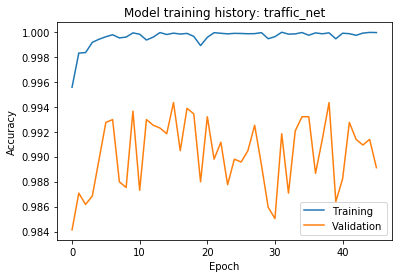

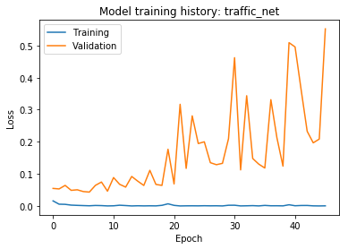

```python
plot_history(history_accuracy, 'traffic_net',image_name='training_accuracy.png')
plot_history(history_loss, 'traffic_net',image_name= 'training_loss.png', ylabel='Loss')
```

### Step 6c : Test Set Performance

```python
with tf.Session() as sess:
    saver.restore(sess, tf.train.latest_checkpoint('.'))
    test_loss, test_accuracy = evaluate(x_test_processed, y_test)
    print('Test accuracy: {:.3f}%'.format(test_accuracy * 100))
    print('Test loss: {:.3f}'.format(test_loss))

    softmax = tf.nn.softmax(logits)
    t_pred = None
    for x_batch, y_batch in batch_generator(x_test_processed, y_test, batch_size):
        top_softmax = sess.run(tf.nn.top_k(softmax, k=5), feed_dict={x: x_batch, y: y_batch, kp: 1.0})
        if t_pred is None:
            t_pred = top_softmax[1]
        else:
            t_pred = np.concatenate([t_pred, top_softmax[1]])
    correct = np.sum([1 for t_pred, actual in zip(t_pred, y_test) if actual in t_pred])
    print('Top-5 Test Image Accuracy: {:.3f}%'.format(100 * correct / len(y_test)))
```

```
INFO:tensorflow:Restoring parameters from ./traffic_net.ckpt
Test accuracy: 97.704%
Test loss: 0.246
Top-5 Test Image Accuracy: 99.628%
```

### Step 6d :Plotting a confusion matrix

THe confusion matrix helps us visualize the wrong classes that get predicted. It the current case, we don't see any major variation.

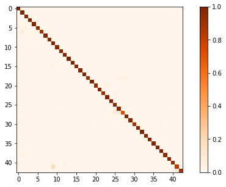

```python
cm = confusion_matrix(y_test, t_pred[:, 0])
cm = cm.astype('float') / cm.sum(axis=1)[:, np.newaxis]  # Normalize
plt.figure(figsize=(10,5))
plt.imshow(cm, interpolation='nearest', cmap=plt.cm.Oranges)
plt.savefig('./output_images/confusion_matrix.png')
plt.colorbar()
```

### Step 7 : Inference Pipeline

```
INFO:tensorflow:Restoring parameters from ./traffic_net.ckpt
```

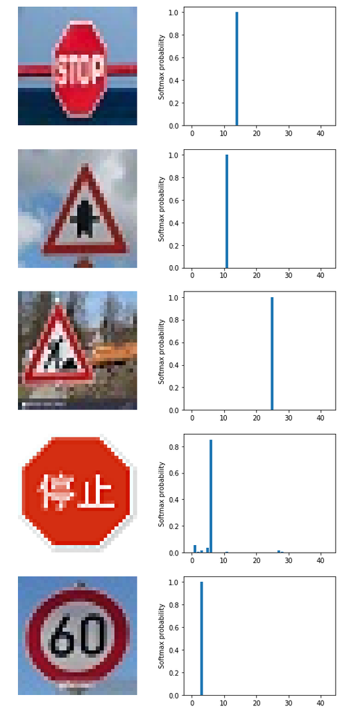

```python
fig, axs = plt.subplots(5,2, figsize=(9, 19))
axs = axs.ravel()
preprocessed_image = []
with tf.Session() as sess:
    saver.restore(sess, tf.train.latest_checkpoint('.'))
    softmax = tf.nn.softmax(logits)

    raw_images = glob.glob('input_images/*.jpg')
    for i,image in enumerate(raw_images):
        img = cv2.imread(image)
        test_image = np.expand_dims(img,axis=0)
        test_image = processor.preprocess(test_image)
        preprocessed_image.append(test_image)
        softmax_logits = sess.run(softmax, feed_dict={x: test_image,  kp: 1.0})
        top_logits = sess.run(tf.nn.top_k(softmax, k=5), feed_dict={x: test_image,  kp: 1.0})

        # Plottig the Graph
        axs[2*i].axis('off')
        axs[2*i].imshow(cv2.cvtColor(img, cv2.COLOR_BGR2RGB))
        axs[2*i+1].bar(np.arange(n_classes), softmax_logits[0])
        axs[2*i+1].set_ylabel('Softmax probability' )

fig.savefig('./output_images/new_prediction.png')
```

## Visualizing Feature Maps

```
INFO:tensorflow:Restoring parameters from ./traffic_net.ckpt
Feature maps for Speed limit (80km/h)
```

[figure not shown]

```
First convolutional layer
```

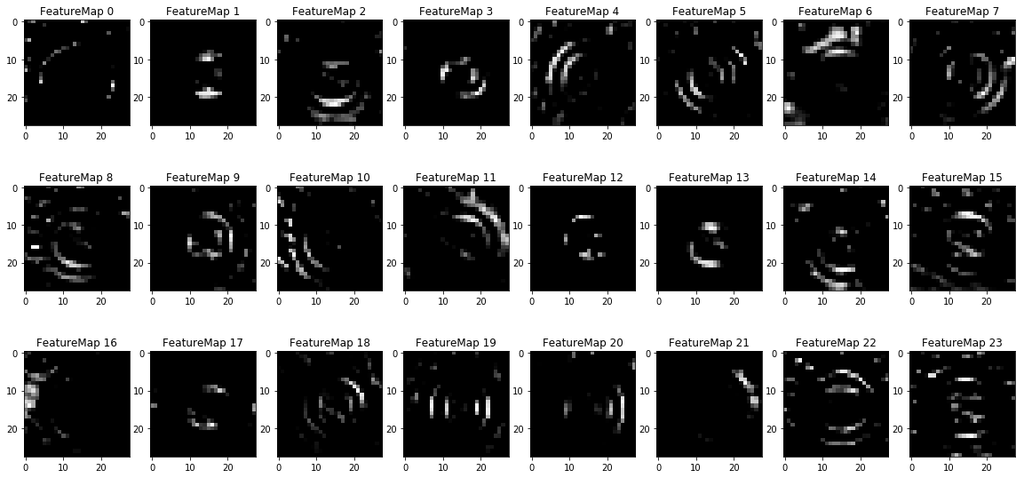

```
Second convolutional layer
```

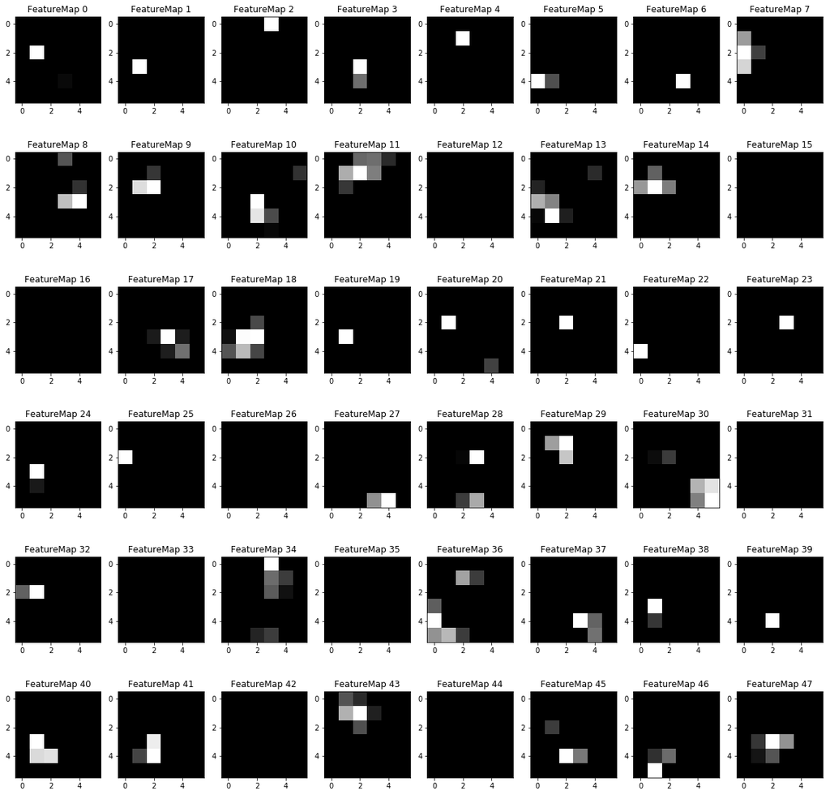

```python
def outputFeatureMap(image_input, tf_activation, activation_min=-1, activation_max=-1 ,plt_num=1):
    # Here make sure to preprocess your image_input in a way your network expects
    # with size, normalization, ect if needed
    # image_input =
    # Note: x should be the same name as your network's tensorflow data placeholder variable
    # If you get an error tf_activation is not defined it maybe having trouble accessing the variable from inside a function
    activation = tf_activation.eval(session=sess,feed_dict={x : image_input})
    featuremaps = activation.shape[3]
    plt.figure(plt_num, figsize=(20,20))
    for featuremap in range(featuremaps):
        plt.subplot(6,8, featuremap+1) # sets the number of feature maps to show on each row and column
        plt.title('FeatureMap ' + str(featuremap)) # displays the feature map number
        if activation_min != -1 & activation_max != -1:
            plt.imshow(activation[0,:,:, featuremap], interpolation="nearest", vmin =activation_min, vmax=activation_max, cmap="gray")
        elif activation_max != -1:
            plt.imshow(activation[0,:,:, featuremap], interpolation="nearest", vmax=activation_max, cmap="gray")
        elif activation_min !=-1:
            plt.imshow(activation[0,:,:, featuremap], interpolation="nearest", vmin=activation_min, cmap="gray")
        else:
            plt.imshow(activation[0,:,:, featuremap], interpolation="nearest", cmap="gray")

with tf.Session() as sess:
    saver.restore(sess, tf.train.latest_checkpoint('.'))
    ix = int(np.random.random() * x_test_processed.shape[0])
    random_image = np.expand_dims(x_test_processed[ix], axis=0)
    print('Feature maps for', signnames[y_test[ix]])
    plt.imshow(x_test[ix])
    plt.show()
#     plt.savefig('./output_images/'+signnames[y_test[ix]] + '_visualization.png')
    print('First convolutional layer')
    outputFeatureMap(random_image, conv1, plt_num=1)
    plt.show()
#     plt.savefig('./output_images/'+signnames[y_test[ix]] + '_feature_map1.png')
    print('Second convolutional layer')
    outputFeatureMap(random_image, conv2, plt_num=2)
    plt.show()
#     plt.savefig('./output_images/'+signnames[y_test[ix]] + '_feature_map2.png')
```